# Reading and Displaying inForm Image Files

Kent Johnson

2017-07-25

inForm writes a variety of image files in JPEG and TIFF format. This vignette shows how to read the image files in R.

The R packages `tiff` and `jpeg` provide functions `readTIFF` and `readJPEG` which read image data into R matrices. `phenoptr` expands on these with `read_components` and `read_maps` which read multiple images and extract useful metadata from the Image Description fields.

A variety of functions can display image data including `plot.raster`, `ggplot2::annotation_raster` and `EBImage::display`.

## Coordinate systems

A few items to note:

- Images have the origin (0, 0) at the top left. This is consistent with the `Cell X Position` and `Cell Y Position` columns of an inForm cell seg table. The *row* (first) dimension of an array corresponds to the $y$ axis and `Cell Y Position` column. The *column* (second) array dimension corresponds to the $x$ axis and the `Cell X Position` column.
- Image dimensions are in pixels. Cell seg tables are written with pixel dimensions and converted to microns when read by `phenoptr::read_cell_seg_data`.
- Image display methods differ in their orientation; some show $x$ and $y$ as described above; others transpose the image.

Each of these items easily causes confusion; be careful and verify your work!

## Reading and displaying color images

Color (RGB) images output from inForm, such as the composite image and segmentation images, can be read directly using `tiff::readTIFF()` or `jpeg::readJPEG()`. For example,

```r
path = system.file("extdata", "sample",
                   "Set4_1-6plex_[16142,55840]_composite_image.jpg",
                   package = "phenoptr")
img = jpeg::readJPEG(path)
dim(img)
```

```
[1] 1400 1868    3
```

Color images are read as 3D arrays. They can be displayed by converting to a raster.

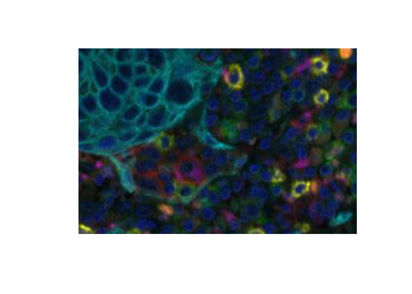

```r
snippet = as.raster(img[800:1000, 1200:1500,])
plot(snippet)
```

`EBImage::display` will display an array in a web browser. RGB images are shown as three grayscale planes unless converted to an `EBImage::Image` first. `EBImage::display` shows the first coordinate horizontally and the second coordinate vertically so the image must be flipped to display in the expected orientation.

```r
img_transposed = aperm(img, c(2, 1, 3))
EBImage::display(img_transposed)
EBImage::display(EBImage::Image(img_transposed, colormode='Color'))
```

## Reading and displaying component data

inForm saves component data as multiple 32-bit floating-point images within a single TIFF file. Images smaller than 2K by 2K pixels are saved in “strip” format and may be read by `tiff::readTIFF()`. Larger images are saved in “tiled” format which is not supported by `readTIFF()`. The [`RBioFormats`](https://github.com/aoles/RBioFormats) package may be an alternative for reading larger component data files.

`phenoptr::read_components()` is a wrapper around `readTIFF()` which reads the individual component images from a `component_data.tif` file. It keeps the full-resolution component images, extracts the component names from the image descriptions, and returns a named list of image matrices.

Component data may be displayed using `plot.raster` or `EBImage::display`. See the next section for examples of displaying grayscale images.

## Reading and displaying segmentation maps

inForm saves segmentation maps (nuclear segmentation, etc.) as multiple 16-bit grayscale images within a single TIFF file. Most segmentation images are *label* images, where each object is represented by a region whose value is the object number. The membrane map is a binary image where the presence of membrane is indicated with a “1” value.

`phenoptr::read_maps()` is a wrapper around `readTIFF()` which reads map files. It returns a named list of integer-valued matrices. The list names reflect the content of the individual images, e.g. Nucleus, Cytoplasm, etc.

```r
map_path = system.file("extdata", "sample",
   "Set4_1-6plex_[16142,55840]_binary_seg_maps.tif", package = "phenoptr")
maps = phenoptr::read_maps(map_path)
names(maps)
```

```
[1] "Nucleus"   "Cytoplasm" "Membrane"  "Tissue"
```

The Nucleus label image contains values for background (0) and each Cell ID.

```r
nucleus = maps[['Nucleus']]
dim(nucleus)
```

```
[1] 1400 1868
```

```r
range(nucleus)
```

```
[1]    0 6183
```

```r
range(phenoptr::sample_cell_seg_data$`Cell ID`)
```

```
[1]   11 6183
```

Label images may be displayed with `plot.raster` or `EBImage::display` (which requires swapping axes).

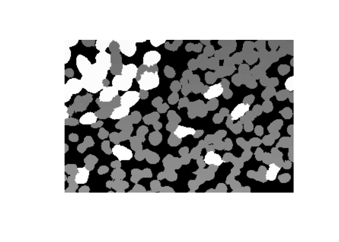

```r
nucleus_snippet = nucleus[800:1000, 1200:1500]
plot(as.raster(nucleus_snippet, max=max(nucleus_snippet)))
```

```r
EBImage::display(t(nucleus/max(nucleus)))
EBImage::display(t(maps[['Membrane']]))
```

## Plotting image data

Images have the origin (0, 0) at the top left. This is consistent with the `Cell X Position` and `Cell Y Position` columns of an inForm cell seg table but it is reversed (in $y$) from the usual plotting conventions. If you plot images and points together, you will have to reverse one or the other.

Here is an example using `ggplot2`. The $y$-axis is reversed using `ggplot2::scale_y_reverse()` and the image is then un-reversed by negating its $y$ limits.

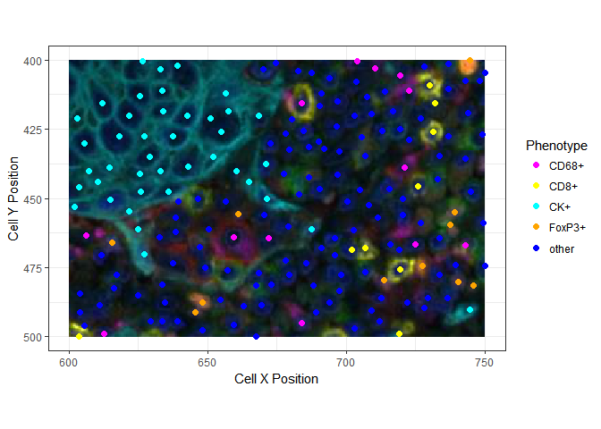

```r
library(ggplot2)
csd = phenoptr::sample_cell_seg_data
csd = subset(csd, `Cell X Position`>=600 & `Cell X Position`<=750 &
              `Cell Y Position`>=400 & `Cell Y Position`<=500)
ggplot(data=csd, aes(`Cell X Position`, `Cell Y Position`, color=Phenotype)) +
  scale_x_continuous(limits=c(600, 750)) +
  scale_y_reverse(limits=c(500, 400)) +
  annotation_raster(snippet, 600, 750, -400, -500) +
  geom_point(size=2) + coord_equal() +
  scale_color_manual(values=c("CK+"="cyan", "CD8+"="yellow",
                              "other"="blue", "CD68+"="magenta",
                              "FoxP3+"="orange"))
```